ex1: I understand and will follow the submission rules.

ex2: I ended up by choosing the merge sort algorithm. Here below you can find the code of it.

```python
def mergeSort(mlist):
    if len(mlist)>1:
        mid = len(mlist)//2
        lefthalf = mlist[:mid]
        righthalf = mlist[mid:]

        mergeSort(lefthalf)
        mergeSort(righthalf)

        return merge(lefthalf, righthalf, mlist)

def merge(lefthalf, righthalf, mlist):
        i=0
        j=0
        k=0
        while i < len(lefthalf) and j < len(righthalf):
            if lefthalf[i] < righthalf[j]:
                mlist[k]=lefthalf[i]
                i=i+1
            else:
                mlist[k]=righthalf[j]
                j=j+1
            k=k+1

        while i < len(lefthalf):
            mlist[k]=lefthalf[i]
            i=i+1
            k=k+1

        while j < len(righthalf):
            mlist[k]=righthalf[j]
            j=j+1
            k=k+1
```

my setup for the test would be like this: The maximum integer value is 9223372036854775807. The algorithm is merge sort n will go up to 1000 The merge_sort() algorithm behaves in the following way when increasing the n parameter up to n = 1000:

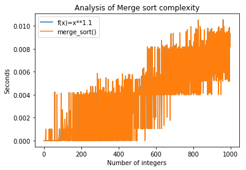

```python
import random, sys, time, numpy, math
import matplotlib.pyplot as plott

def increase(n):
    measures = []
    f_x = []
    for j in range(1, n):
        randomArr = numpy.array(numpy.random.randint(0,9223372036854775807,j, dtype=numpy.int64)).tolist()
        startTime = time.time()
        mergeSort(randomArr)
        duration = time.time() - startTime
        measures.append(duration)
        f_x.append(numpy.power(j,0.00012) * duration)
    plott.title("Analysis of Merge sort complexity")
    plott.ylabel('Seconds')
    plott.xlabel('Number of integers')

    plott.plot(f_x, label='f(x)=x**1.1')
    plott.plot(measures, label='merge_sort()')
    plott.legend()
    plott.show()
increase(1000)
```

ex3: Phyton's the most used sorting function is Timsort. Timsort is a hybrid sorting algorithm, derived from merge sort and insertion sort, designed to perform well on many kinds of real-world data. It was invented by Tim Peters in 2002 for use in the Python programming language. The algorithm finds subsets of the data that are already ordered, and uses the subsets to sort the data more efficiently. This is done by merging an identified subset, called a run, with existing runs until certain criteria are fulfilled. Timsort has been Python's standard sorting algorithm since version 2.3. The estimated Big O of this algorithm is n∗log(n)/45.

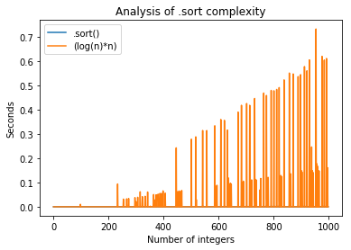

```python
def increasing(n):
    measures = []
    f_x = []
    for j in range(1, n):
        randomArr = numpy.array(numpy.random.randint(0,9223372036854775807,j, dtype=numpy.int64)).tolist()
        startTime = time.time()
        randomArr.sort()
        duration = time.time() - startTime
        measures.append(duration)
        f_x.append((numpy.log(j) * duration * j)/45)
    plott.title("Analysis of .sort complexity")
    plott.ylabel('Seconds')
    plott.xlabel('Number of integers')

    plott.plot(measures, label='.sort()')
    plott.plot(f_x, label='(log(n)*n)')
    plott.legend()
    plott.show()
increasing(1000)
```

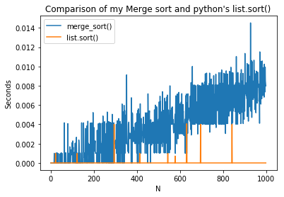

```python
def compare_the_diff(n):
    measures = []
    python_sort_measures = []
    for j in range(1, n):

        randomArr = numpy.array(numpy.random.randint(0,9223372036854775807,j, dtype=numpy.int64)).tolist()
        start = time.time()
        mergeSort(randomArr)
        duration = time.time() - start
        measures.append(duration)

        start = time.time()
        randomArr.sort()
        duration2 = time.time() - start
        python_sort_measures.append(duration2)

    plt.title("Comparison of my Merge sort and python's list.sort()")
    plt.ylabel('Seconds')
    plt.xlabel('N')

    plt.plot(measures, label='merge_sort()')
    plt.plot(python_sort_measures, label='list.sort()')
    plt.legend(loc='upper left')
    plt.show()
compare_the_diff(1000)
```

It's not properly seen but Timsort is much more efficient than merge sort that I applied

ex5: for \begin{equation*} f(n) = 4^3 + 0.5n , g(n) = n^3 \end{equation*} we should prove that f(n) = Theta(g(n)) by finding suitable c1, c2 and n0. Firstly we should prove that f(n)∈O(g(n))∩Ω(g(n))

O(g(n)):

f(n)∈O(g(n))⟺0 ≤ f(n) ≤ c1∗g(n) for any n≥n0 with c1>0,n0>0. It means that \begin{equation*} 0≤4n^3+0.5n≤c1∗n^3 \end{equation*}

This assertion is only true when c1≥4.5

The limit of the comparison should then be positive to prove that in this case, g(n) is always bigger than f(n) for any $n > n_0$ :

$\lim_{n \to \infty} \frac{4.5 n^{3}}{4 n^{3} + 0.5 n} = \lim_{n \to \infty} \frac{4.5}{4 + \frac{0.5}{n^{2}}} = 1.125 \Longrightarrow positive$

For any $n > n_0$ , this term is positive. As such, $f(n) \in O(g(n)).$

$\Omega(g(n))$:

$f(n) \in \Omega(g(n)) \Longleftrightarrow 0 \leq c_2 * g(n) \leq f(n)$ for any $n \geq n_0$ with $c_2 > 0, n_0 > 0$ that means that $0 \leq c_2 * n^{3} \leq 4n³ + 0.5n.$ This assertion is only true when $c_2 \leq 4.$

$\Theta(g(n))$

We know now that $f(n) \in O(g(n)) \cap \Omega(g(n))$, thus, $f(n) \in \Theta(g(n)).$